# changeLOS: An R-package for change in length of hospital stay based on the Aalen-Johansen estimator

Abstract

“changeLOS: An R-package for change in length of hospital stay based on the Aalen-Johansen estimator” published in R News.

## Introduction

Length of hospital stay (LOS) is used to assess the utilization of hospital resources, the costs and the general impact of a disease. Change in LOS due to a complication is frequently used to assess the impact and the costs of a complication. Prominent examples include nosocomial infections and adverse drug events. In a data analysis, it is important to regard the timing of events: A complication can only have an effect on LOS, once it has occurred. Classical methods of two-group comparison, including matching, are commonly used, but inadequate. Multi-state models provide a suitable framework for analyzing change in LOS. For an overview on multi-state models cf. (Andersen and Keiding, 2002). Change in LOS has been considered in a multi-state framework by (Schulgen and Schumacher, 1996), (Schulgen et al., 2000), (Beyersmann et al., 2006) and (Beyersmann, 2005). We introduce an R package to adequately analyze change in LOS. The R package is based on multi-state model theory. The main features are:

- Describe multi-state models
- Compute and plot transition probabilities (Aalen - Johansen estimator)
- Compute and plot change in LOS

The estimation techniques used are fully nonparametric, allowing for a time-inhomogeneous Markov process, i.e. the future development of the process depends only on the state currently occupied; the Markov assumption may be dropped for estimation of state occupation probabilities (Glidden, 2002). However, at present, adjusting for covariates is not included. In both these aspects, the package **changeLOS** differs from the package **msm**.

## Simple example: Competing Risks

A simple example for a multi-state model is the competing risks model, shown in the following figure:

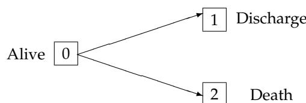

Figure 1: Multi-state model: competing risks

With our R package **changeLOS** it is possible to:

- describe the state names and possible transitions (function **msmodel(…)**):

  |  | 0 | 1 | 2 |
  | --- | --- | --- | --- |
  | 0 | TRUE | TRUE | TRUE |
  | 1 | FALSE | TRUE | FALSE |
  | 2 | FALSE | FALSE | TRUE |

- compute the Aalen-Johansen estimator for the matrix of transition probabilities (function **aj(…)**): $\mathbf{P}(\mathbf{s}, \mathbf{t})$, time interval $(s, t]$. These are the Cumulative Incidence Functions: $P_{01}(0, t)$, $P_{02}(0, t)$
- plot the temporal dynamics of the data illustrated by transition probabilities (function **plot.aj(…)**):

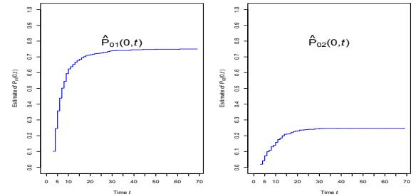

Figure 2: Cumulative Incidence Functions

## Change in LOS

### The model

The following model is used to analyze change in LOS due to a complication, or in general, an intermediate event:

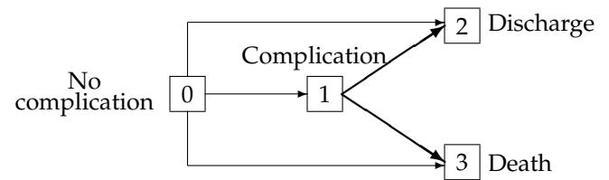

Figure 3: Multi-state model: change in LOS

The first step is to describe the mult-state model with the function **msmodel(…)**:

```
## possible transitions
> tra <- matrix(F, 4, 4)
> diag(tra) <- T
> tra[1, ] <- T
> tra[2, 3:4] <- T
## describe the multi-state model
> my.model <- msmodel(c("0","1","2","3"),
                      tra, cens.name="cens")
```

### The data set

A real data set (Grundmann et al., 2005) comes with the package and can be loaded by and looks like the following example:

```
> data(los.data)
> los.data[1:4,]
```

|  | adm.id | j.01 | j.02 | j.03 | j.12 | j.13 | cens |
| --- | --- | --- | --- | --- | --- | --- | --- |
| 1 | 12 | Inf | 3 | Inf | Inf | Inf | Inf |
| 2 | 32 | Inf | Inf | 20 | Inf | Inf | Inf |
| **3** | **41** | **20** | **Inf** | **Inf** | **40** | **Inf** | **Inf** |
| 4 | 175 | 6 | Inf | Inf | Inf | Inf | 26 |
| . | . | . | . | . | . | . | . |

`los.data` has one row per patient and includes the variables `j.01`, `j.02`, `j.03`, `j.12`, `j.13` and `cens`. The variables starting with ‘j’ will hold the time when a respective transition (or ‘jump’) was observed. E.g., the third patient experiences a complication 20 days after admission to hospital and is being discharged 40 days after admission. Entries for non-observed transitions have to be set to infinity, which is represented in R by `Inf`. In addition, if a patient is censored, i.e. still in hospital by the end of the study, the variable `cens` is set to the time when censoring occurred. If the patient is not censored, it is set to `Inf`.

Before further computations, the patient-orientated data set `los.data` must be transformed to a transition-orientated data set:

```
> my.observ <- prepare.los.data(x=los.data)
```

Then the data set looks like:

|  | id | from | to | time |
| --- | --- | --- | --- | --- |
| 1 | 12 | 0 | 2 | 3 |
| 2 | 32 | 0 | 3 | 20 |
| **3** | **41** | **0** | **1** | **20** |
| **4** | **41** | **1** | **2** | **40** |
| 5 | 175 | 0 | 1 | 6 |
| 6 | 175 | 1 | cens | 26 |
| . | . | . | . | . |

Now each row represents a transition. E.g. for the patient with the id 41 there are two entries: one entry for the transition from state 0 to state 1 and one entry for the transition from state 1 to state 2.

## The Aalen-Johansen estimator

```
> my.trans <- trans(model=my.model,
                    observ=my.observ)
```

computes the Aalen - Johansen estimator for the matrix of transition probabilities $P(u-, u)$ for all observed transition times $u$. The entry $(l, m)$ of the matrix denotes the estimated probability that state $m$ has been reached by time $u$ given state $l$ has been occupied just before time $u$. The estimator for $P(u-, u)$ is described by (Andersen et al., 1993) at the bottom of p. 288. Non-diagonal entries $(h, j)$ are given as the number of observed transitions from state $h$ to state $j$, divided by the number of individuals in state $h$ just prior to time $u$. The diagonal elements are chosen such that the sum of each row equals 1.

The Aalen-Johansen estimator for $P(s, t)$ can then be computed as matrix product of all matrices $P(u-, u)$ for all transition times $u$ in $(s, t]$:

```
> my.aj <- aj(my.trans, s=0, t=80)
```

The temporal dynamics of the data can be illustrated by the transition probabilities:

```
> plot(my.aj, c("0", "0", "0", "0", "1", "1"),
       c("0", "1", "2", "3", "2", "3"))
```

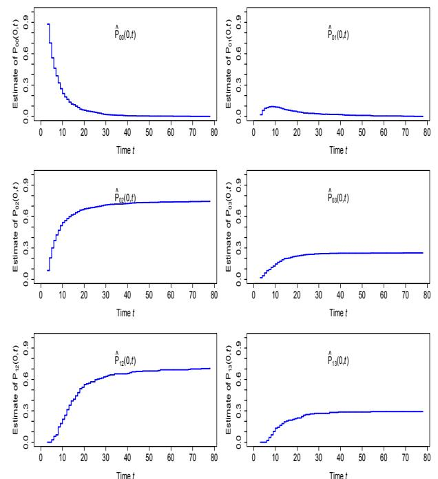

Figure 4: Aalen -Johansen estimator for \(P_{00}(s, t)\) , \(P_{01}(s, t)\) , \(P_{02}(s, t)\) , \(P_{03}(s, t)\) , \(P_{12}(s, t)\) , \(P_{13}(s, t)\)

## Epected change in LOS

The function `clos` estimates the expected change in length of stay (LOS) associated with an intermediate event (IE), using the Aalen-Johansen estimator for the matrix of transition probabilities.

```
> los <- clos(model=my.model, observ=my.observ)
```

`los` will be a an object of class `clos`. This object is a list which contains among others the following arguments:

- `cLOS`: change in LOS
- `e.given.1`: estimates $E(LOS | \text{state 1 on day } t)$ for each day
- `e.given.0`: estimates $E(LOS | \text{state 0 on day } t)$ for each day
- `weights`: weights for the weighted average
- `trans`: matrices of transition probabilities $P(u-, u)$ for all observed transition times $u$

The expected change in LOS is computed as the difference between `e.given.1` and `e.given.0` for each day and the overall change in LOS `cLOS` as a weighted average of these quantities. Figure 5 shows the graph obtained by plotting *change in LOS*:

```
> plot(los, xlim=c(0,80), ylim.1=c(0,120))
```

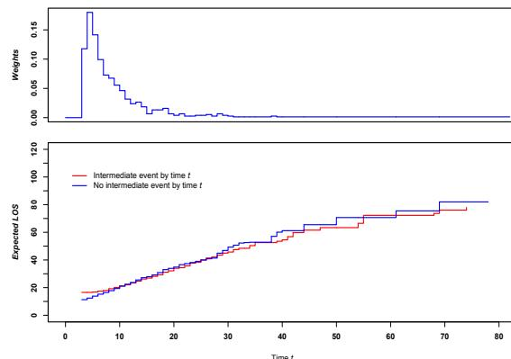

Figure 5: Expected change in LOS due to a complication visualized

```
> summary(los)
```

The summary for objects of class `c1os` displays the following values (absolute and in percent):

- Number of observed patients
- Number of patients being discharged
- Number of patients who die
- Number of patients being censored
- Number of patients who experienced the intermediate event (IE)
- Number of patients who experienced the IE being discharged
- Number of patients who experienced the IE and died
- Number of patients who experienced the IE and were censored

### Progressive Disability Model

Change in LOS and impact of an intermediate event on mortality can also be investigated in a so-called progressive disability model, shown in Figure 6. This multi-state model can be described and the Aalen-Johansen estimator for transition probabilities can be computed with our R package **changeLOS**:

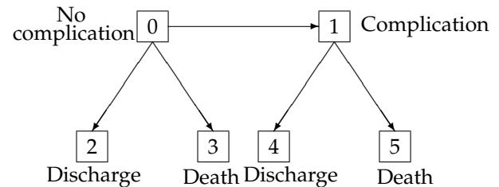

Figure 6: Progressive disability model

## Summary

In order to get realistic information on change in LOS due to a complication, it is crucial to adequately account for the timing of events. This can be achieved as outlined by (Beyersmann et al., 2006). However, while tools of standard survival analysis have become an integral part of most statistical software packages, the multi-state methods envisaged by (Beyersmann et al., 2006) and (Beyersmann, 2005) are less accessible. We have introduced the R package **changeLOS** so that it is freely available, easy to use and allows people to visualize the situation at hand.

**changeLOS** is an R package to:

- describe any multistate model
- compute and visualize transition probabilities (Aalen-Johansen estimator)
- compute and visualize change in LOS

## References

- P. Andersen, Ø. Borgan, R. D. Gill, and N. Keiding. *Statistical models based on counting processes*. Springer Series in Statistics. New York, NY: Springer., 1993.
- P. Andersen and N. Keiding. Multi-state models for event history analysis. *Statistical Methods in Medical Research*, 11(2):91–115, 2002.
- J. Beyersmann. *On change in length of stay associated with an intermediate event: estimation within multi-state models and large sample properties*. PhD thesis, University of Freiburg, Faculty of Mathematics and Physics, Germany, 2005. URL www.freidok.uni-freiburg.de/volltexte/1843/.
- J. Beyersmann, P. Gastmeier, H. Grundmann, S. Bärwolff, C. Geffers, M. Behnke, H. Rüden, and M. Schumacher. Use of Multistate Models to Assess Prolongation of Intensive Care Unit Stay Due to Nosocomial Infection. *Infection Control and Hospital Epidemiology*, 27:493–499, 2006.
- D. Glidden. Robust innference for event probabilities with non-Markov data. *Biometrics*, 58:361–368, 2002.
- H. Grundmann, S. Bärwolff, F. Schwab, A. Tami, M. Behnke, C. Geffers, E. Halle, U. Göbel, R. Schiller, D. Jonas, I. Klare, K. Weist, W. Witte, K. Beck-Beilecke, M. Schumacher, H. Rüden, and P. Gastmeier. How many infections are caused

by patient-to-patient transmission in intensive care units? *Critical Care Medicine (in press)*, 2005.

- G. Schulgen, A. Kropec, I. Kappstein, F. Daschner, and M. Schumacher. Estimation of extra hospital stay attributable to nosocomial infections: heterogeneity and timing of events. *Journal of Clinical Epidemiology*, 53:409–417, 2000.
- G. Schulgen and M. Schumacher. Estimation of prolongation of hospital stay attributable to nosocomial infections. *Lifetime Data Analysis*, 2:219–240, 1996.